# Lab7

Jesse and Ryan

GitHub URL: https://github.com/s1075803/lab7

## 1

```r
quiz <- read.csv('quiz.csv', sep = ',')
```

## 2

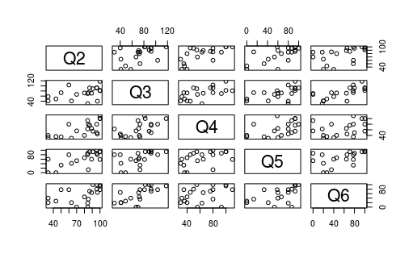

```r
plot(quiz)
```

The quiz grades seem to have a weak positive association with each other. This is because if you consider the upper half plots, the data points seem to trend upward. Since each successive quiz is plotted on the horizontal access and the prior quizes are plotted on the vertical axis, the weak positive association in each graph indicates that each successive quiz is associated with a lower quiz score than the previous quiz. In other words, the weak positive association indicates decreasing quiz scores because of the way that the pairs plot was plotted.

## 3

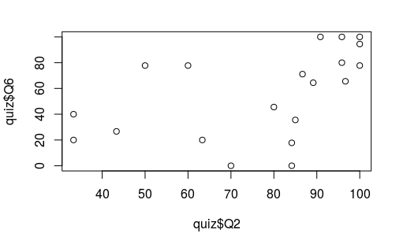

```r
plot(quiz$Q2,quiz$Q6)
```

## 4

Yes the Pearson Correlation test shows a positive correlation between Quiz 2 and 6.

```r
cor(quiz$Q2, quiz$Q6)
```

```
[1] 0.4909938
```

Since the Pearson correlation is 0.4909938, which is between 0 and 1, the Pearson correlation indicates a positive association between quiz percentages.

## 5

```r
#' The single.boot function creates a single bootstrap for a sample
#' of random vectors where each random vector contains 2 random
#' variables. Then, the correlation of that bootstrap is computed.
#'
#' @param x The first of 2 random variables in each random vector.
#' @param y The second of 2 random variables in each random vector.
#'
#' @return The sample correlation of the bootstrap.

single.boot<-function(x, y){

  indicies <- sample(length(x), replace=TRUE)

  boot.corr <- cor(x[indicies], y[indicies])

  return(boot.corr)

}

#single.boot(quiz$Q2, quiz$Q6)
```

```r
bootstrap.cor <- function(x, y, B = 2000){

correlation <- replicate(B, single.boot(x, y))

return(correlation)

}

#bootstrap.cor(quiz$Q2, quiz$Q6)
```

## 6

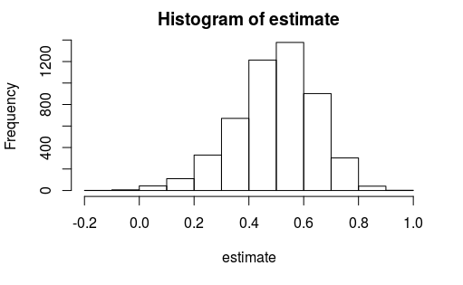

```r
set.seed(0)

estimate <- bootstrap.cor(x = quiz$Q2, y = quiz$Q6, B = 5000)

hist(estimate)
```

The histogram is left-skewed with most observations between 0.5 and 0.6, the second most obeservations between 0.4 and 0.5, and the vast majority of observations between 0 and 1. An extremely small proportion of the observations are negative, and the observations that are negative are between -0.2 and 0.

## 7

```r
quantile(estimate, c(0.025,0.975))
```

```
     2.5%     97.5%
0.1792492 0.7585798
```

```r
test <- cor.test(x = quiz$Q2, y = quiz$Q6, conf.level = 0.95)

test$conf
```

```
[1] 0.06192856 0.76688885
attr(,"conf.level")
[1] 0.95
```

A 95% bootstrap percentile confidence interval for the correlation between the Quiz 2 and Quiz 6 percentages is (0.1792, 0.7586) and a 95% confidence interval using Fisher’s Z-transformation is (0.0619, 0.7669). The two confidence intervals are similar, but the confidence interval using Fisher’s Z-transformation is objectively more conservative than the bootstrap percentile confidence interval because the former’s lower estimate is lower than the latter’s lower estimate and the former’s upper estimate is higher than the latter’s upper estimate. You can reject the null hypothesis that there is no association between a student’s Quiz 2 and Quiz 6 scores using both confidence intervals because 0 is not contained within either confidence interval. Note, however, that rejecting the null hypothesis using both confidence intervals works at a 95% confidence interval. At a higher significance level, you might be able to reject the null hypothesis with the bootstrap percentile confidence interval but not the Fisher’s Z-transformation confidence interval. At an even higher significance level, you might be unable to reject the null hypothesis with either confidence interval.

## 8

```r
cov.mat <- cov(quiz)

cov.mat
```

```
         Q2       Q3       Q4       Q5        Q6
Q2 499.5980 230.7018 371.5351 485.8772  370.3947
Q3 230.7018 539.2333 345.7544 384.4834  544.4574
Q4 371.5351 345.7544 637.4842 374.9825  308.9532
Q5 485.8772 384.4834 374.9825 996.0936  565.6725
Q6 370.3947 544.4574 308.9532 565.6725 1139.0871
```

```r
cov.mat[1, 2]
```

```
[1] 230.7018
```

```r
cov(quiz$Q2, quiz$Q3)
```

```
[1] 230.7018
```

The (1, 2) entry in cov.mat matches the covariance we get from passing the Quiz 2 and Quiz 3 percentages to the x and y arguments of cov(). This entry is 230.7018.

## 9

```r
eigen.vals <- eigen(cov.mat)$values

eigen.vals
```

```
[1] 2446.15631  611.37990  435.12267  221.17157   97.66563
```

The eigenvalues are sorted in decreasing order.

## 10

```r
sum(eigen.vals)
```

```
[1] 3811.496
```

```r
sum(diag(cov.mat))
```

```
[1] 3811.496
```

Yes, the sum of the eigenvalues of the covariance matrix matches the sum of the variances across all of the scores because both sums are equal to 3811.496.

## 11

```r
eigen.vals[1]/sum(eigen.vals)
```

```
[1] 0.6417838
```

The proportion of the variance is captured by the first principal component is 0.6417838.

## 12

```r
bootstrap.eigenratio.single <- function(mat){

  boot.mat <- mat[sample(1:nrow(mat), replace = TRUE), ]

  cov.mat <- cov(boot.mat)

  eigen.vals <- eigen(cov.mat)$values

  ratio.single <- eigen.vals[1]/sum(eigen.vals)

  return(ratio.single)

}
```

```r
bootstrap.eigenratio <- function(mat, B = 2000){

ratio.multiple <- replicate(B, bootstrap.eigenratio.single(mat))

return(ratio.multiple)

}

#bootstrap.eigenratio(quiz)
```

## 13

```r
set.seed(0)

estimate <- bootstrap.eigenratio(mat = quiz, B = 5000)
```

```r
quantile(estimate, c(0.025,0.975))
```

```
     2.5%     97.5%
0.4958144 0.7970077
```